# Statistical Models for Election Polling

Oct 29, 2018

First, we load a few R packages

```r
library(tidyverse)
```

# Motivation

“All models are wrong, but some are useful” -George E. P. Box

We have implicitly been using a very simple linear models. We have been trying to predict a fixed parameter by taking samples. For example, we have tried to estimate the proportion of individuals who will vote for a republican candidate or the difference in the proportion of votes two candidates, for example Obama and Romney, will receive. Here, we will us general notation and represent the parameter we are trying to estimate with $\theta$. We then obtain draws from a sampling model.

We will denote the observed values with $Y$ and use indexes to denote the fact that we make, say, $N$ observations:

$$Y_i = \theta + \varepsilon_i, i = 1, \dots N$$

Each observation has an *error* term $\varepsilon$. We assume that the expected value of the error is 0 and very often assume that the standard deviation is constant $\sigma$.

# Data Wrangling

We will use 2012 Presidential Election (Obama vs Romney) poll data for this lecture. We’ve already learned how to use the [`pollstR`](https://cran.r-project.org/web/packages/pollstR/index.html) R package to extract historical poll data.

```r
library(pollstR)
library(lubridate)
race2012 <- pollster_charts_polls(slug = '2012-general-election-romney-vs-obama')

polls2012 <- race2012$content %>%
  select(Obama, Romney, margin_of_error, observations,
         start_date, end_date, survey_house) %>%
  mutate(Obama = Obama*0.01,
         Romney = Romney*0.01,
         diff = Obama - Romney,
         margin_of_error=ifelse(is.na(margin_of_error),0,margin_of_error)*0.01,
         days = start_date - ymd('2012-11-06'),
             weeks = floor(days/7)) %>%
  rename(n=observations)
head(polls2012)
```

```
## # A tibble: 6 x 10
##   Obama Romney margin_of_error     n start_date end_date   survey_house
##   <dbl>  <dbl>           <dbl> <int> <date>     <date>     <chr>
## 1  0.47   0.47           0.031  1000 2012-11-04 2012-11-05 Politico/GWU/B…
## 2  0.49   0.47           0       740 2012-11-03 2012-11-05 YouGov/Economi…
## 3  0.48   0.48           0.033   872 2012-11-03 2012-11-05 Gravis Marketi…
## 4  0.5    0.49           0.037   712 2012-11-03 2012-11-05 IBD/TIPP
## 5  0.48   0.49           0.03   1500 2012-11-03 2012-11-05 Rasmussen
## 6  0.47   0.47           0.031  1041 2012-11-03 2012-11-05 JZ Analytics/N…
## # ... with 3 more variables: diff <dbl>, days <time>, weeks <time>
```

# Exploratory Data Analysis

First, let’s figure out how many polls we have? and on average, how big are the individual poll sample sizes?

```r
nrow(polls2012)
```

```
## [1] 428
```

```r
summary(polls2012$n, na.rm=TRUE)
```

```
##    Min. 1st Qu.  Median    Mean 3rd Qu.    Max.    NA's
##     563     885    1067    1368    1500   36472      14
```

Oh ok, so we have some polls without sample sizes. Let’s remove those.

```r
polls2012 <- polls2012[!is.na(polls2012$n), ]
```

We can use a scatter plot to show the number of polls (y-axis) for each week (x-axis).

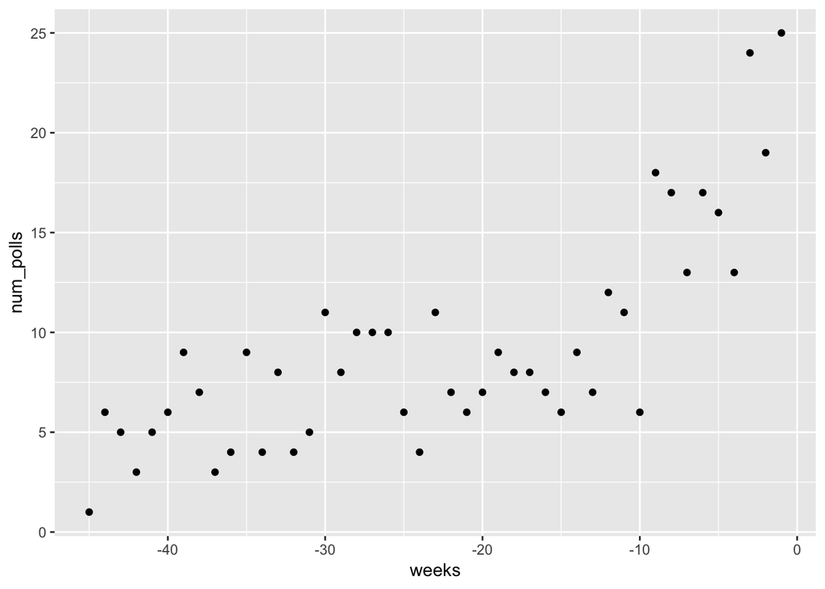

```r
polls2012 %>%
    group_by(weeks) %>%
    summarize(num_polls=n()) %>%
    ggplot(aes(weeks, num_polls)) +
        geom_point()
```

We see many of the polls 10-20 weeks prior to the election only had a handful of polls.

We can also explore how the different pollsters have a different distribution for the differences.

First, let’s see which are the pollsters with the most polls:

```r
head(sort(table(polls2012$survey_house),
          decreasing = TRUE))
```

```
##
##             Rasmussen      YouGov/Economist                Gallup
##                    98                    40                    35
## DailyKos/SEIU/PPP (D)                   FOX   Ipsos/Reuters (Web)
##                    28                    15                    14
```

Let’s keep the top ten pollsters

```r
top_pollsters <-
  names(sort(table(polls2012$survey_house), decreasing = TRUE)[1:10])
top_pollsters
```

```
##  [1] "Rasmussen"                 "YouGov/Economist"
##  [3] "Gallup"                    "DailyKos/SEIU/PPP (D)"
##  [5] "FOX"                       "Ipsos/Reuters (Web)"
##  [7] "CNN"                       "Pew"
##  [9] "Politico/GWU/Battleground" "ABC/Post"
```

We can use boxplots to plot the distribution of the difference between Obama and Romney stratified by pollster.

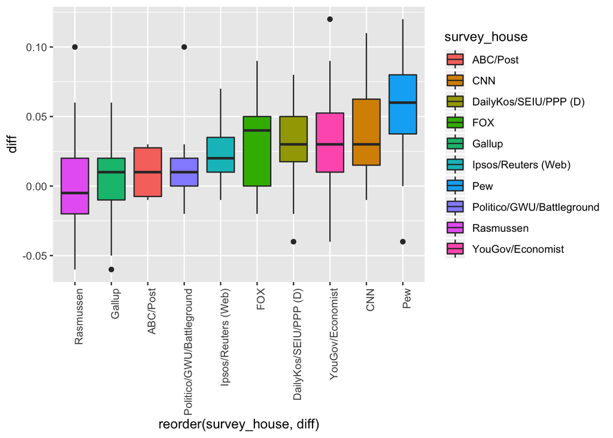

```r
polls2012 %>%
    filter(survey_house %in% top_pollsters) %>%
    ggplot(aes(reorder(survey_house, diff), diff, fill=survey_house)) +
  geom_boxplot() +
  theme(axis.text.x = element_text(angle = 90, hjust = 1))
```

We get the sense that many pollsters were reporting differences in favor of Obama, but some were favoring Romney. Let’s try and estimate the true difference between Obama and Romney using poll data.

# Linear models

The goal of using linear models is to try and estimate some parameter $\theta$ by observing draws from a sampling model.

If we define $Y_i$ as the observed difference in each poll between Obama and Romney, we can write a linear model:

$$Y_i = \theta + \varepsilon_i, i=1, \dots, N$$

where $Y_1, Y_2, \ldots, Y_N$ are the observed values with $N$ total observations, $\theta$ is the true difference in the polls on election night and $N$ is the number of polls we observe (i.e. in our dataset: $N=$414).

Each observation has an *error* term $\varepsilon_i$ that defines the difference between the true parameter value ($\theta$) and the observed value ($Y_i$).

How do we model $\varepsilon$? We assume that the expected value of the error term is 0 and very often assume the standard deviation is a contant $\sigma$.

In the next few sections, we will explore how to estimate $\theta$ and $\sigma$

## Sampling model

We define the sampling distribution as

$$Y | \theta \sim N(\theta, \sigma^2/N)$$

where

- $Y$ is the observed difference in each poll between Obama and Romney
- $\theta$ is the true difference in the polls on election night
- $\sigma^2$ is the observed sample variance
- $N$ is the number of polls we observe (i.e. each poll is an observation here)

## Estimating parameters

### Estimate $\theta$

Previously, we have hinted at how we can aggregate results using what amounts to a weighted average. For example, in our example, we can create an estimate of $\theta$ using the standard approach to fitting linear models (e.g. minimizing the least squares equation):

$$\sum_{i=1}^N (Y_i - \theta)^2$$

This is called the *least squares estimate* (LSE). In this case is easy to show, with calculus, that it is the sample average:

$$\hat{\theta} = \frac{1}{N}\sum_{i=1}^N Y_i = \bar{Y}$$

For example, we can take the sample average across all polls in our dataset with sample sizes ranging from 1000 to 1500:

```r
polls2012 %>%
    filter(n > 1000 & n < 1500) %>%
    summarize(tot_poll = n(),
              theta_hat = mean(diff))
```

```
## # A tibble: 1 x 2
##   tot_poll theta_hat
##      <int>     <dbl>
## 1       71    0.0158
```

which is not so far off from the 3.9% true difference on the 2012 election night.

Now, recall from the sampling model that the expectation of $Y$ is $\theta$ and the standard error is $\sigma / \sqrt{N}$ with $N$ the number of observations and $\sigma$ the standard deviation of the distribution of $\varepsilon$.

So how can we estimate $\sigma$?

### Estimate $\sigma$

There are two main ways to estimate $\sigma$:

1. Using the Central Limit theorem (theoretical)
2. Using the sample standard deviation (empirical)

#### 1. Using Central Limit Theorem (theoretical)

If we have one poll with sample size $n$ (e.g. $n=1500$), and if $p$ is the proportion of individuals voting for just one candidate (e.g. republicans), the CLT tells us that the standard error for $\hat{p}$ is

$$\frac{\sqrt{p (1-p)}}{\sqrt{n}}$$
But, if we are estimating the difference in percentages between two candidates ($\theta$), then the estimate is approximated by

$$\hat{\theta} = \hat{p} - (1-\hat{p}) = 2\hat{p} - 1$$
.

This implies that the standard error of $\hat{\theta}$ is

$$2 \sqrt{ p (1 - p)} / \sqrt{n}$$

Therefore, because each $Y_i$ a separate poll then the standard deviation of $\varepsilon$ should be about $2 \sqrt{ p (1 - p) }/ \sqrt{n}$:

or

$$\varepsilon \sim \mbox{Normal}\left( 0, \frac{2\sqrt{p (1-p)}}{\sqrt{n}} \right)$$

where $n$ is the poll size from a single poll. In our example, let’s consider all polls of size ranging from 1000 to 1500 and estimate $\sigma$:

```r
polls2012 %>%
  filter(n > 1000 & n < 1500) %>%
  summarize(theta_hat = mean(diff),
            sigma_hat_theor = 2 * sqrt(mean(Romney)*(1-mean(Romney))) / sqrt(1250))
```

```
## # A tibble: 1 x 2
##   theta_hat sigma_hat_theor
##       <dbl>           <dbl>
## 1    0.0158          0.0282
```

This theory is extremely useful when we just have one poll.

However, if we are fortunate enough to be able to observe multiple polls results (e.g. polls from different pollsters or polls from different weeks over time), we can use the poll data directly to estimate $\sigma$ (instead of using the statistical theory above).

#### 2. Using sample standard deviation (empirical)

The typical strategy is to use the sample standard deviation formula:

$$s = \sqrt{ \frac{1}{N-1}\sum_{i=1}^N (Y_i - \bar{Y})^2}$$

where $N$ is the total number of polls we observe. In our case, we can use the `sd()` function:

```r
polls2012 %>%
  filter(n > 1000 & n < 1500) %>%
  summarize(theta_hat = mean(diff),
            sigma_hat_emp = sd(diff))
```

```
## # A tibble: 1 x 2
##   theta_hat sigma_hat_emp
##       <dbl>         <dbl>
## 1    0.0158        0.0315
```

**IMPORTANT**: Do not confuse the poll sample size $n$ with the number of observations in our model above $N$. In the model above we treat each poll as a single observation and we observe $N$ polls. But it is important to keep in mind that each poll we observe had a poll size associated with it (i.e. $n$).

# Confidence intervals

Next, we will use the CLT to construct a 95% confidence interval for $\hat{\theta}$ using the empirical (and then theoretical) approach to estimate the standard deviation $\sigma$.

```r
ests <- polls2012 %>%
    filter(n > 1000 & n < 1500) %>%
    summarize(tot_poll = n(),
              theta_hat = mean(diff),
              sigma_hat_emp = sd(diff),
              sigma_hat_theor = 2 * sqrt(mean(Romney)*(1-mean(Romney))) / sqrt(1250))
ests
```

```
## # A tibble: 1 x 4
##   tot_poll theta_hat sigma_hat_emp sigma_hat_theor
##      <int>     <dbl>         <dbl>           <dbl>
## 1       71    0.0158        0.0315          0.0282
```

Recalling the standard error or $\theta$ is $\sigma / \sqrt{N}$ with $N$ the number of observations and $\sigma$ the standard deviation of the distribution of $\varepsilon$, then a 95% confidence interval using the empirical approach to estimate $\sigma$ is:

```r
ests$theta_hat +
    c(-1,1) * (ests$sigma_hat_emp / sqrt(ests$tot_poll)) * qnorm(0.975)
```

```
## [1] 0.008443643 0.023105652
```

And a 95% confidence interval using the theoretical approach to estimate $\sigma$ is:

```r
ests$theta_hat +
    c(-1,1) * (ests$sigma_hat_theor / sqrt(ests$tot_poll)) * qnorm(0.975)
```

```
## [1] 0.009216525 0.022332771
```

## Why does the theory not match what we see in the data?

In general, if the model is a good fit to the data, the empirical estimate of $\sigma$ should match what the the statistical theory says it should be. Recall this is our model:

$$Y_i = \theta + \varepsilon_i, i = 1, ..., N$$

Instead, we see the empirical estimate of $\sigma$ is larger than what the theory says it should be. Why is this??

Well, there are many possible reasons for this. Let’s consider three reasons:

#### 1. Time effect

One possible reason is that if there is a strong time (or “week”) effect, then there is extra variability in the data that is not being accounted for in the model.

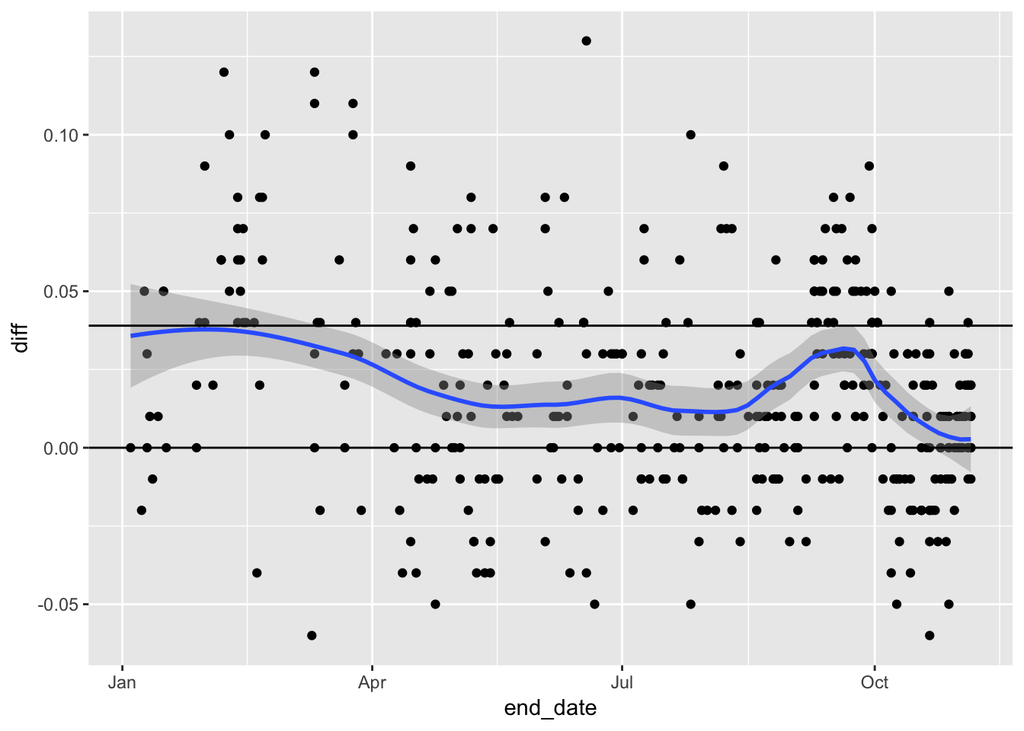

```r
polls2012 %>%
    group_by(weeks) %>%
    mutate(num_polls=n()) %>%
    filter(num_polls >= 5) %>%
    ungroup() %>%
    ggplot(aes(end_date, diff)) + geom_point() +
        geom_smooth(span=0.5) + geom_hline(aes(yintercept=0)) +
        geom_hline(aes(yintercept=0.039))
```

We could modify the model to include another term $w_t$ that represents the time (or “week”) effect.

$$Y_{t,i} = \theta + w_t + \varepsilon_{t,i}$$

**Note**: We now have two indexes $t$ denoting week and $i$ an index for the $i$-th poll during week $t$.

By including this extra term in our model, we are saying that the variability observed in the polls does not just come from $\varepsilon$. We are saying there is extra or additional variabilty from time that we are ignoring.

We can model the time effects $w_t$ by making assumptions about the expected value and variance of of $w_t$. For example, in more formal statistics classes you can learn about analysis of variance which does confirm strong week effect:

```r
tab <- polls2012 %>%
          group_by(weeks) %>%
            mutate(num_polls=n()) %>%
            filter(num_polls >= 5) %>%
            ungroup() %>%
          group_by(survey_house) %>%
            filter(n() > 10)
fit <- lm(diff ~ weeks, data=tab)
summary(aov(fit))
```

```
##              Df  Sum Sq  Mean Sq F value   Pr(>F)
## weeks         1 0.01793 0.017931   15.85 9.06e-05 ***
## Residuals   242 0.27376 0.001131
## ---
## Signif. codes:  0 '***' 0.001 '**' 0.01 '*' 0.05 '.' 0.1 ' ' 1
```

#### 2. House effect

Another possible reason is from what’s called a *house effect* or pollster effect. If there was no pollster effect, we would expect the distributions (or boxplots) of the difference between Obama and Romney to be similar.

However, that’s not what we see:

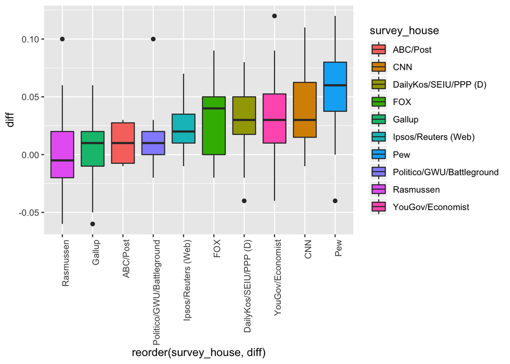

```r
polls2012 %>%
    filter(survey_house %in% top_pollsters) %>%
    ggplot(aes(reorder(survey_house, diff), diff, fill=survey_house)) +
        geom_boxplot() +
        theme(axis.text.x = element_text(angle = 90, hjust = 1))
```

If we see that each pollster has a different distribution in the difference between Obama and Romney. We could modify the model to include another term $p_j$ that represents the pollster effect.

$$Y_{t,i,j} = \theta + w_t + p_{j} + \varepsilon_{t,i,j}$$

where $p_{j}$ a pollster effect for the $j^{th}$ pollster. By including this extra term in our model, we are saying that the variability observed in the polls does not just come from $\varepsilon$. We are saying there is extra or additional variabilty from the pollsters.

And in fact, we do see a strong week and house effect:

```r
tab <- polls2012 %>%
          group_by(weeks) %>%
            mutate(num_polls=n()) %>%
            filter(num_polls >= 5) %>%
            ungroup() %>%
          filter(survey_house %in% top_pollsters)
fit <- lm(diff ~ weeks + survey_house, data=tab)
summary(aov(fit))
```

```
##               Df  Sum Sq  Mean Sq F value   Pr(>F)
## weeks          1 0.01810 0.018100   22.30 3.94e-06 ***
## survey_house   9 0.07924 0.008805   10.85 3.69e-14 ***
## Residuals    243 0.19721 0.000812
## ---
## Signif. codes:  0 '***' 0.001 '**' 0.01 '*' 0.05 '.' 0.1 ' ' 1
```

We can model the pollster specific effects $p_j$ by making an assumption about the expected value of $p_j$ (e.g. $\mbox{E}(p_j)=0$) and we can model the pollster specific effects to have different variances. To estimate these we can use previous election data. With these in place, we can construct weighted estimates for $\theta$ that better estimate the variablity.

#### 3. General biases

The last possible reason we’ll consider here is from what are called *general biases* that have not been accounted for. Specifically, our assumption that $\mbox{E}(p_j)=0$ is incorrect. This assumption says that, on average, pollsters are not biased, but this is not the case. Instead we need to add a general bias to the model

$$Y_{t,i,j} = \theta + w_t + p_j + b + \varepsilon_{t,i,j}.$$

But note we cannot estimate $b$ from the data: this model is not identifiable. However, we can model $b$ as a random effect with and estimate its variance from past elections where we know $\theta$.

# 2018 Senate midterm elections

In the United States, we will hold [elections for our Senate](https://en.wikipedia.org/wiki/United_States_Senate_elections,_2018) on November 6, 2018 with 33 of the 100 seats being contested in regular elections and 2 seats being contested in special elections. These are positions are for six-year terms (Jan 3, 2019 to Jan 3, 2025).

The reason there are 33 Senate seats is because the we have three [classes in US Senate](https://en.wikipedia.org/wiki/Classes_of_United_States_Senators) made up of 33 or 34 Senate seats each. One class of senate seats is up for election every two years (staggering the three groups so not all senators are up re-election at a given time).

For example, the 33 Senate seats of class 1 will be up for election in 2018, the elections for the 33 seats of class 2 will take place in 2020, and the elections for the 34 seats of class 3 will be held in 2022.

For this lecture we will focus on the [Senate race in Florida](https://www.realclearpolitics.com/epolls/2018/senate/fl/florida_senate_scott_vs_nelson-6246.html) between Bill Nelson (D) and Rick Scott (R).

First we will read in the data.

```r
library(rvest)
state_url <- "https://www.realclearpolitics.com/epolls/2018/senate/fl/florida_senate_scott_vs_nelson-6246.html"
h <- read_html(state_url)
```

What does the data look like:

```r
tmp <- h %>%
  html_table() %>%
  .[[4]] %>%
  as_tibble() %>%
  filter(Poll != "RCP Average")
tmp
```

```
## # A tibble: 40 x 7
##    Poll              Date     Sample MoE   `Nelson (D)` `Scott (R)` Spread
##    <chr>             <chr>    <chr>  <chr>        <dbl>       <dbl> <chr>
##  1 NY Times/SienaNY… 10/23 -… 737 LV 4.0             48          44 Nelso…
##  2 CBS News/YouGovC… 10/23 -… 991 LV 4.0             46          46 Tie
##  3 GravisGravis      10/22 -… 773 LV 3.5             49          45 Nelso…
##  4 St. Pete PollsSt… 10/20 -… 1575 … 2.5             48          49 Scott…
##  5 WCTV-TVWCTV-TV    10/16 -… 800 LV 3.5             46          45 Nelso…
##  6 Florida Atlantic… 10/18 -… 740 LV 3.6             41          42 Scott…
##  7 Bay News 9/Surve… 10/18 -… 665 LV 5.0             49          41 Nelso…
##  8 QuinnipiacQuinni… 10/17 -… 1161 … 3.5             52          46 Nelso…
##  9 CNNCNN            10/16 -… 759 LV 4.2             50          45 Nelso…
## 10 St. Pete PollsSt… 10/15 -… 1974 … 2.2             47          49 Scott…
## # ... with 30 more rows
```

Next, we will do some data wrangling

```r
polls <- tmp %>%
  mutate(R = `Scott (R)`/100,
         D = `Nelson (D)`/100,
         diff = D-R) %>%
  separate(col=Date, into=c("start_date", "end_date"),
           sep=" - ", fill = "right") %>%
  mutate(start_date = mdy(paste0(start_date,"/18")),
         end_date = mdy(paste0(end_date,"/18")),
         days = start_date - ymd('2018-11-06'),
             weeks = floor(days/7)) %>%
  separate(Sample, into=c("n", "pop_type"),
           sep=" ", fill="left") %>%
  mutate(n = as.numeric(n)) %>%
      select(-MoE, -Spread, -`Scott (R)`, -`Nelson (D)`)
polls
```

```
## # A tibble: 40 x 10
##    Poll     start_date end_date       n pop_type     R     D    diff days
##    <chr>    <date>     <date>     <dbl> <chr>    <dbl> <dbl>   <dbl> <tim>
##  1 NY Time… 2018-10-23 2018-10-27   737 LV        0.44  0.48  0.0400 -14
##  2 CBS New… 2018-10-23 2018-10-26   991 LV        0.46  0.46  0      -14
##  3 GravisG… 2018-10-22 2018-10-23   773 LV        0.45  0.49  0.0400 -15
##  4 St. Pet… 2018-10-20 2018-10-21  1575 LV        0.49  0.48 -0.01   -17
##  5 WCTV-TV… 2018-10-16 2018-10-23   800 LV        0.45  0.46  0.01   -21
##  6 Florida… 2018-10-18 2018-10-21   740 LV        0.42  0.41 -0.01   -19
##  7 Bay New… 2018-10-18 2018-10-21   665 LV        0.41  0.49  0.08   -19
##  8 Quinnip… 2018-10-17 2018-10-21  1161 LV        0.46  0.52  0.06   -20
##  9 CNNCNN   2018-10-16 2018-10-20   759 LV        0.45  0.5   0.0500 -21
## 10 St. Pet… 2018-10-15 2018-10-16  1974 LV        0.49  0.47 -0.02   -22
## # ... with 30 more rows, and 1 more variable: weeks <time>
```

We have a total of $N=$40 observations and the individual poll sample sizes are on average 1002.2:

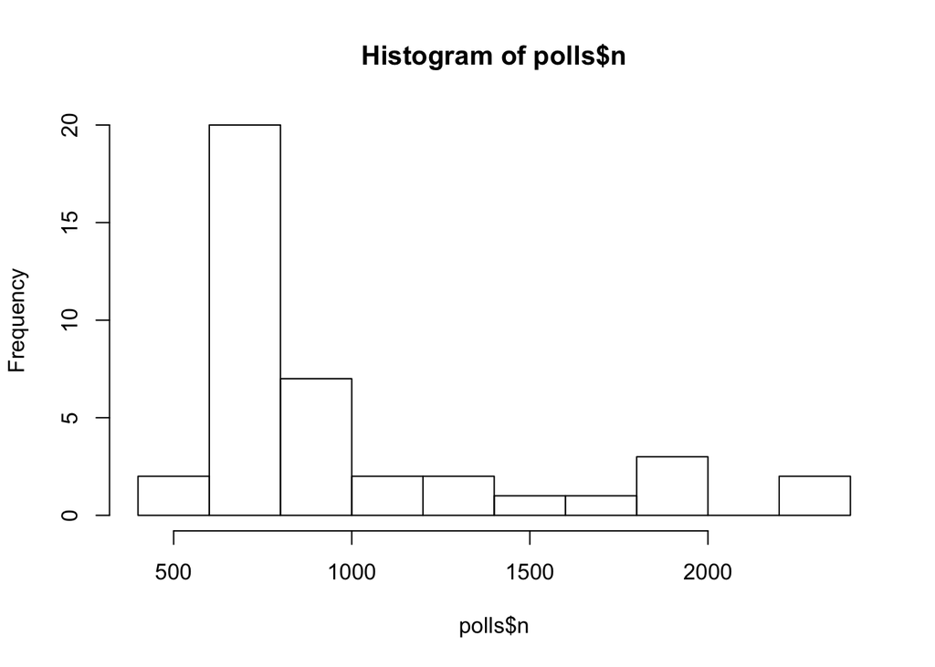

```r
hist(polls$n)
```

We can use a scatter plot to show the number of polls (y-axis) for each week (x-axis).

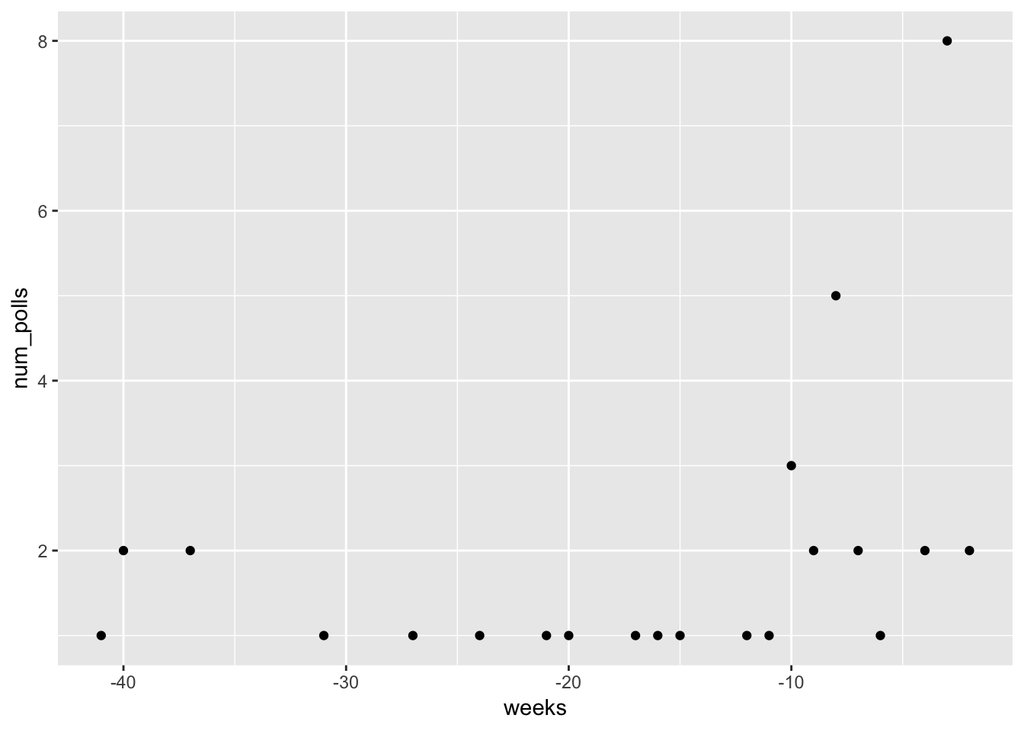

```r
polls %>%
    group_by(weeks) %>%
    summarize(num_polls=n()) %>%
    ggplot(aes(weeks, num_polls)) +
        geom_point()
```

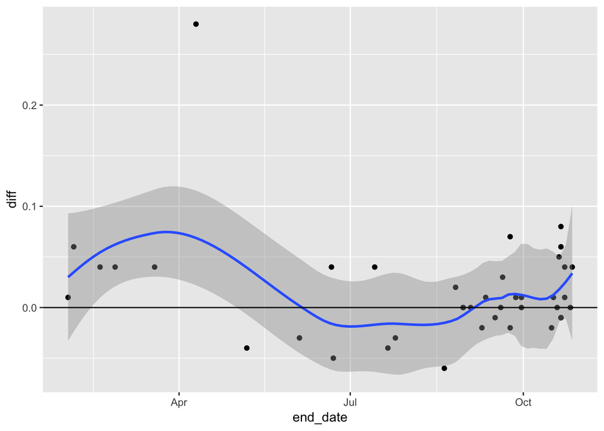

```r
polls %>%
    ggplot(aes(end_date, diff)) +
        geom_point() +
        geom_smooth(span=0.5) +
        geom_hline(aes(yintercept=0))
```

Similar to Obama and Romney, we can use linear models to estimate $\theta$ (difference between Nelson and Scott):

$$Y_i = \theta + \varepsilon_i, i=1, \dots, N$$

with $N=40$. Here I will estimate $\sigma$ using the empirical approach (instead of the theoretical approach using the CLT).

```r
ests <- polls %>%
    summarize(tot_poll = n(),
              theta_hat = mean(diff),
              sigma_hat_emp = sd(diff))
ests
```

```
## # A tibble: 1 x 3
##   tot_poll theta_hat sigma_hat_emp
##      <int>     <dbl>         <dbl>
## 1       40    0.0162        0.0542
```

And a 95% confidence interval using the empirical approach to estimate $\sigma$ is:

```r
ests$theta_hat +
    c(-1,1) * (ests$sigma_hat_emp / sqrt(ests$tot_poll)) * qnorm(0.975)
```

```
## [1] -0.0005442124  0.0330442124
```

Which includes 0, so we will have to call this a toss-up, but it does look like the race is leaning towards Nelson.

We could improve upon this by taking into account biases such as the time or house effect or other general biases using historical data.